# Final

Min Qin

7/31/2020

```r
## 1. Create Univariate analysis for the variable of your interest (your Y variable). Calculate skewness and kurtosis and describe the results.

### Count of different kind of events
str(events)
```

```
## 'data.frame':    2756101 obs. of  5 variables:
##  $ timestamp    : num  1.43e+12 1.43e+12 1.43e+12 1.43e+12 1.43e+12 ...
##  $ visitorid    : int  257597 992329 111016 483717 951259 972639 810725 794181 824915 339335 ...
##  $ event        : Factor w/ 3 levels "addtocart","transaction",..: 3 3 3 3 3 3 3 3 3 3 ...
##  $ itemid       : int  355908 248676 318965 253185 367447 22556 443030 439202 428805 82389 ...
##  $ transactionid: int  NA NA NA NA NA NA NA NA NA NA ...
```

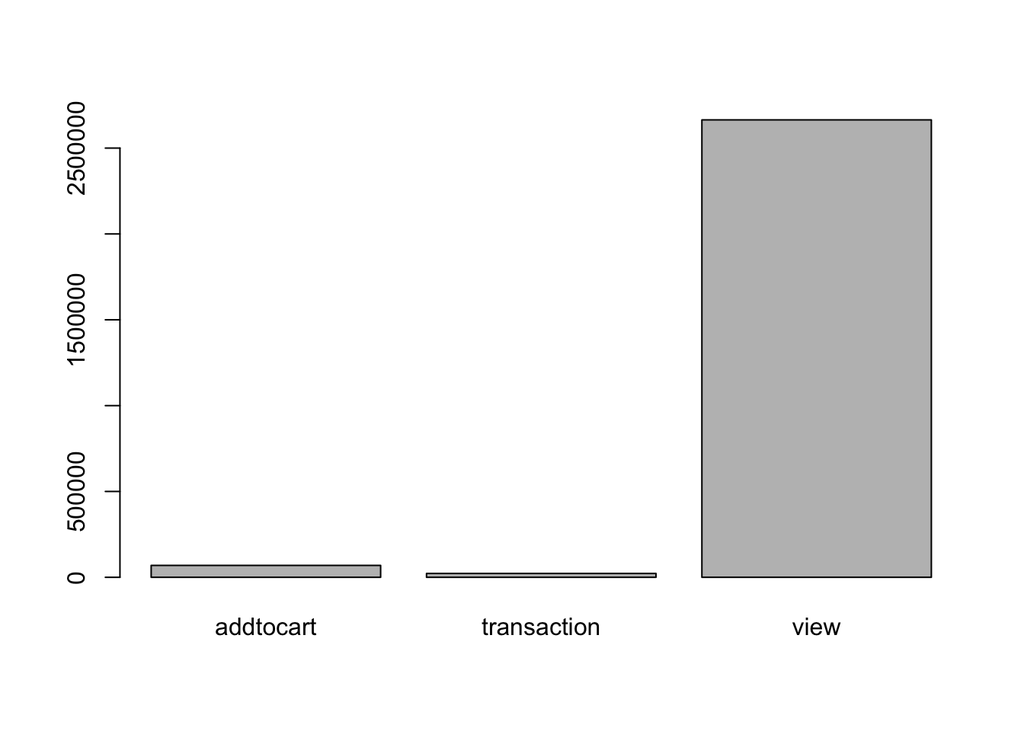

```r
eventCount <- table(events$event)
### Plot the event type
barplot(eventCount)
```

#### Since the event type (Y variable) is categorical, the skewness and kurtosis cannot be assessed. Based on the barplot output and frequency count, there are much more view of products, than add to cart action, than actual purchase of the merchant.

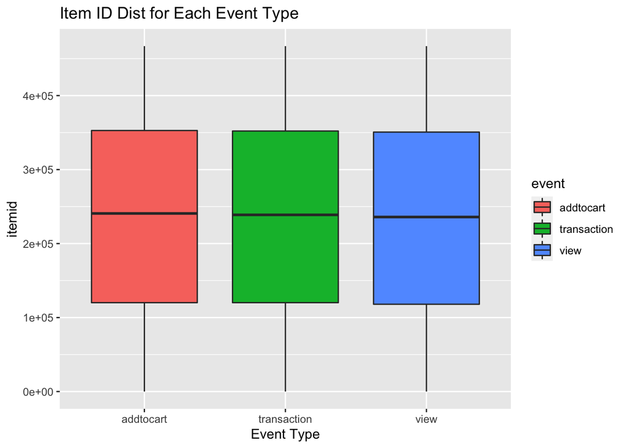

```r
## 2. Create Bivariate plot Box Plot for your Y variable and one of other important metrics (your X). Describe figure.

ggplot(data = events, aes(x=event, y=itemid, fill=event)) + geom_boxplot() +
  ggtitle("Item ID Dist for Each Event Type") +
  xlab("Event Type")
```

#### My type of data does not show well on boxplot. So based on the graph, all items share similar distribution for three different types of transactions.

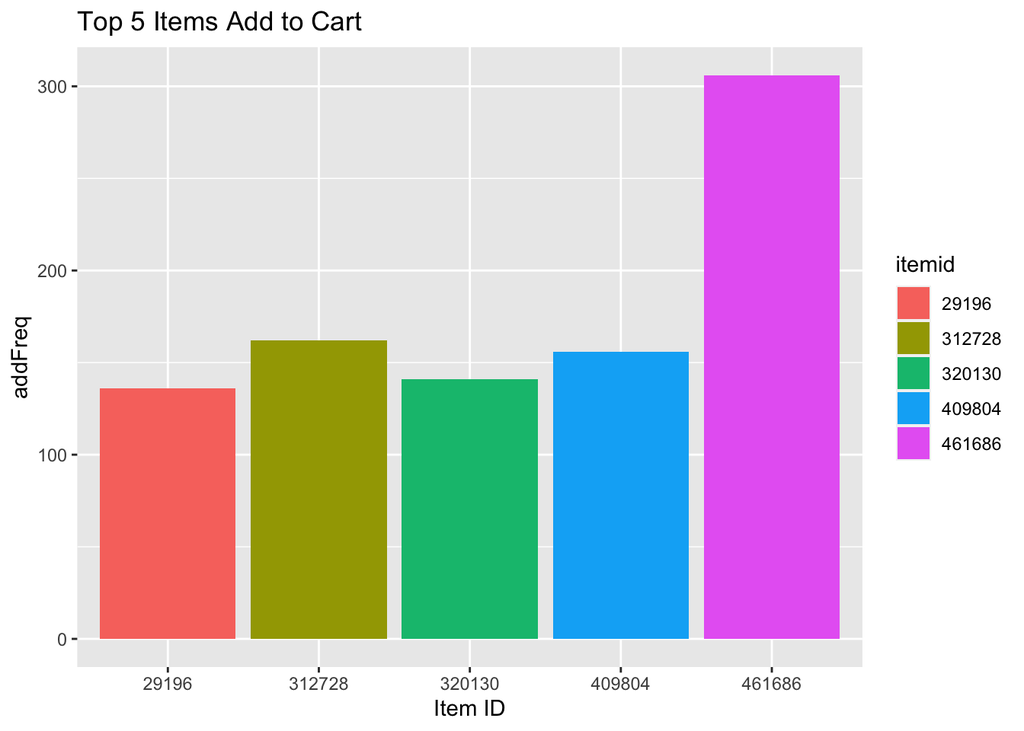

```r
## 3. If your variables are categorical - Create a bar plot.

# filter event type by addtocart only
addCartOnly <- filter(events, event=="addtocart")
itemAddCartCount <- as.data.frame(table(addCartOnly$itemid))
colnames(itemAddCartCount) = c("itemid", "addFreq")
# select 5 tops add to cart items and make bar plot
x <- subset(itemAddCartCount, itemAddCartCount$addFreq >100)
ggplot(x, aes(x = itemid, y = addFreq, fill = itemid)) + geom_bar(stat = "identity") + ggtitle("Top 5 Items Add to Cart") + xlab("Item ID")
```

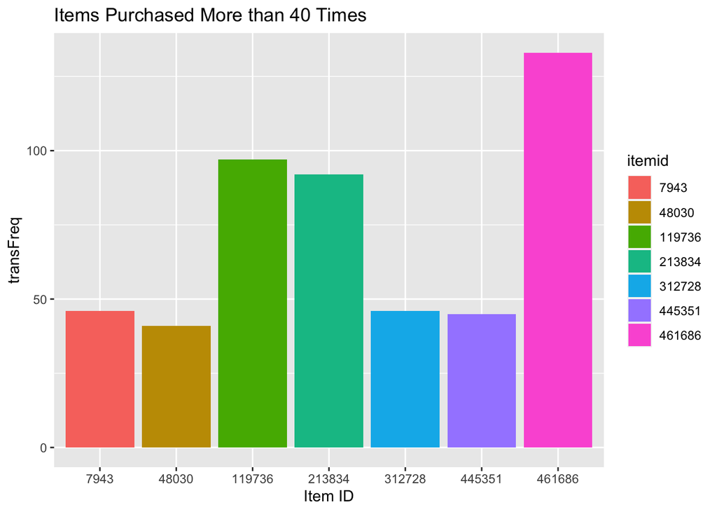

```r
# filter event type by transaction only
transOnly <- filter(events, event=="transaction")
itemTransCount <- as.data.frame(table(transOnly$itemid))
colnames(itemTransCount) = c("itemid", "transFreq")
# select items purchased more than 40 times, and make a bar plot
y <- subset(itemTransCount, itemTransCount$transFreq >40)
ggplot(y, aes(x = itemid, y = transFreq, fill = itemid)) + geom_bar(stat = "identity") + ggtitle("Items Purchased More than 40 Times") + xlab("Item ID")
```

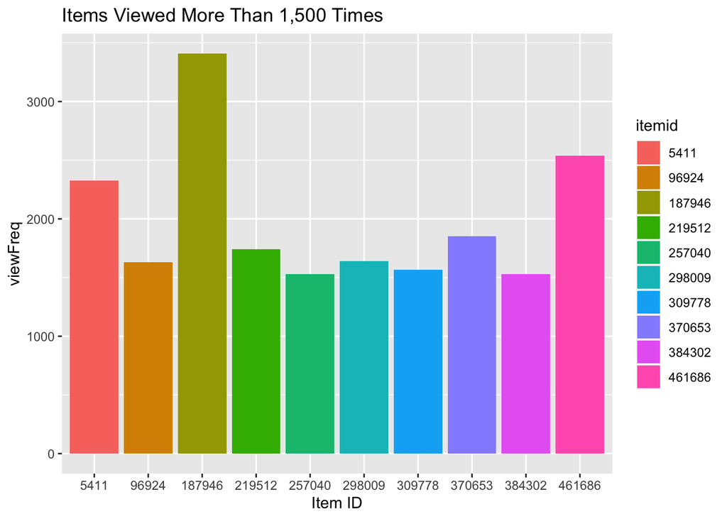

```r
# filter event type by view only
viewOnly <- filter(events, event=="view")
itemViewOnlyCount <- as.data.frame(table(viewOnly$itemid))
colnames(itemViewOnlyCount) = c("itemid", "viewFreq")
# select more than 1,500 views items and make bar plot
z <- subset(itemViewOnlyCount, itemViewOnlyCount$viewFreq >1500)
ggplot(z, aes(x = itemid, y = viewFreq, fill = itemid)) + geom_bar(stat = "identity") + ggtitle("Items Viewed More Than 1,500 Times") + xlab("Item ID")
```

#### Based on the graphs, we can see the most viewed, add to cart and purchased items. And we can see the frequency of each items as well.

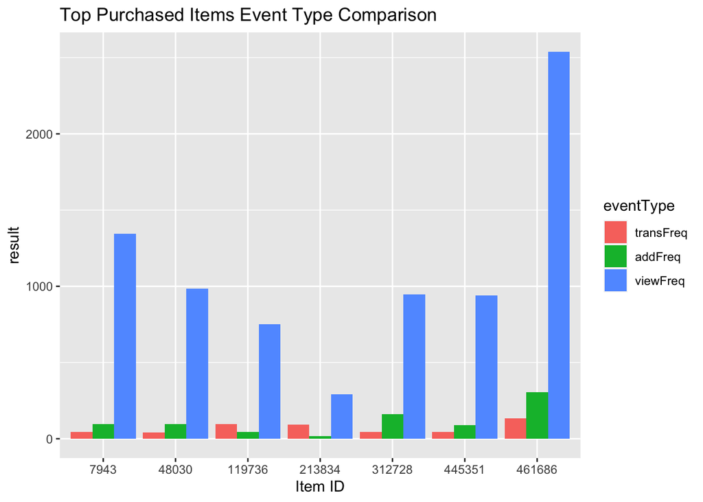

```r
## 4. Create a multivariate plot - Use the same plot as in 3 but add another important variable using colored symbols. Describe Figure. Make sure to add legend.

yx <- merge(y, itemAddCartCount, by="itemid", all.x = TRUE)
yxz <- merge(yx, itemViewOnlyCount, by="itemid", all.x = TRUE)
yxz2 = melt(yxz, id.vars = c("itemid"),
                measure.vars = c("transFreq", "addFreq", "viewFreq"))
yxz2 <- setNames(yxz2, c("itemid", "eventType", "result"))
ggplot(yxz2, aes(x = itemid, y = result, fill = eventType)) +
  geom_bar(stat = "identity", position = 'dodge') +
  ggtitle("Top Purchased Items Event Type Comparison") +
  xlab("Item ID")+
  scale_color_manual(name = "Event Type",
                     labels = c("Transaction",
                                "Add To Cart",
                                "View only"),
                     values = c("Transaction"="red",
                               "Add To Cart"="blue",
                               "View only"="green"))
```

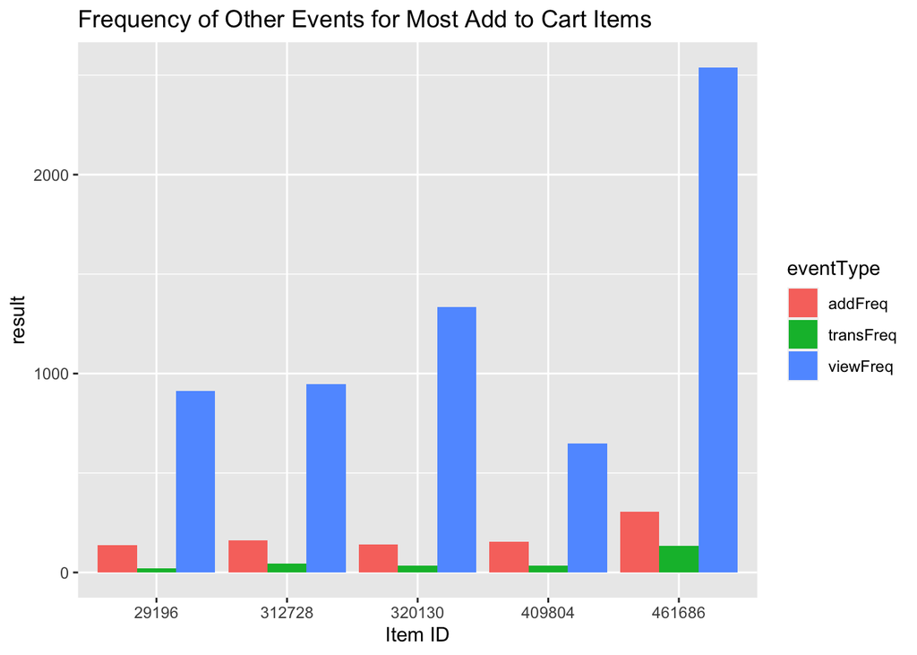

```r
xy <- merge(x, itemTransCount, by="itemid", all.x = TRUE)
xyz <- merge(xy, itemViewOnlyCount, by="itemid", all.x = TRUE)
xyz2 = melt(xyz, id.vars = c("itemid"),
                measure.vars = c("addFreq", "transFreq", "viewFreq"))
xyz2 <- setNames(xyz2, c("itemid", "eventType", "result"))
ggplot(xyz2, aes(x = itemid, y = result, fill = eventType)) +
  geom_bar(stat = "identity", position = 'dodge') +
  ggtitle("Frequency of Other Events for Most Add to Cart Items") +
  xlab("Item ID")+
  scale_color_manual(name = "Event Type",
                     labels = c("Transaction",
                                "Add To Cart",
                                "View only"),
                     values = c("Transaction"="red",
                               "Add To Cart"="blue",
                               "View only"="green"))
```

#### Based on the second graph, for the top 5 most added to cart items, the more add to cart action doesn't necessarily mean the items have more views and will be more likely to be purchased.

```r
## 1. Describe missing data, provide summary of missing data, similar to the analysis in the Chapter 2 (table 3): Count of missing data/percent per variable, type of missing data (NA, null), total percent of missingness per dataset.

sum(is.na(itemProp))
```

```
## [1] 0
```

```r
sum(is.na(events))
```

```
## [1] 2733644
```

```r
sum(is.na(categoryTree))
```

```
## [1] 25
```

```r
(colMeans(is.na(itemProp)))*100
```

```
## timestamp    itemid  property     value
##         0         0         0         0
```

```r
(colMeans(is.na(events)))*100
```

```
##     timestamp     visitorid         event        itemid transactionid
##       0.00000       0.00000       0.00000       0.00000      99.18519
```

```r
(colMeans(is.na(categoryTree)))*100
```

```
## categoryid   parentid
##   0.000000   1.497903
```

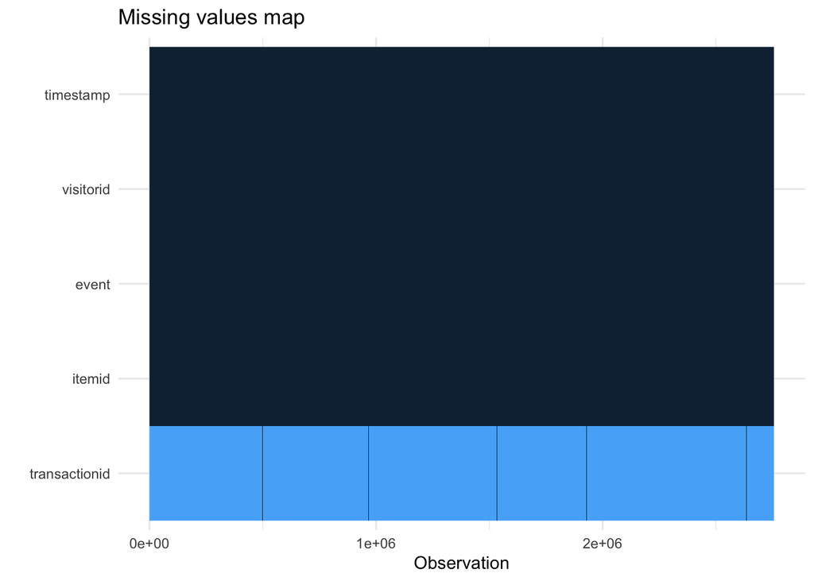

```r
events %>% missing_plot()
```

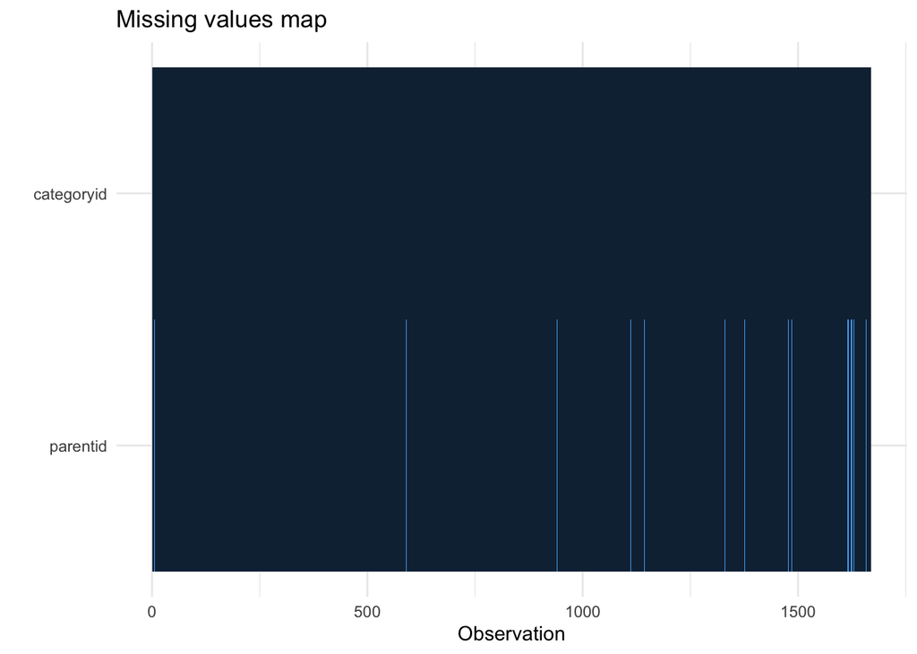

```r
categoryTree %>% missing_plot()
```

#### There is no missing data in item property data. There is 99% of missing data for transaction ID in events data, because only event type as transaction will have transaction ID, view and add to cart action won't have corresbonding transaction ID. There is only 1.5% of missing data in category tree data.

```r
## Step 1. Scale or normalize your data. Make sure to apply imputation if needed.

table(events$event)
```

```
##
##   addtocart transaction        view
##       69332       22457     2664312
```

#### Since I have a pretty clean dataset, each entry has been categorized into different event type. So I cannot eliminate NA value otherwise, everything except transaction (which means product has been purchased instead of only viewed or added to cart) will be ignored. And I don't need to create another factor level for this data since event type is already a factor type, including view, addtocart and transaction.

#### Linear regression model or logistic regression does not really apply to my dataset and I don't plan to use this method in my research. Because I can't and not going to use regression model, so I don't have a summary and interpret table for this situation.

#### My dataset is will be used for train and test to observe and predict customer behavior, so this assignment does not really apply in my case.

```r
## Step 1 - Data Description
str(itemProp)
```

```
## 'data.frame':    20275902 obs. of  4 variables:
##  $ timestamp: num  1.44e+12 1.44e+12 1.44e+12 1.43e+12 1.43e+12 ...
##  $ itemid   : int  460429 206783 395014 59481 156781 285026 89534 264312 229370 98113 ...
##  $ property : Factor w/ 1104 levels "0","1","10","100",..: 1097 973 440 865 1006 1096 233 655 221 496 ...
##  $ value    : Factor w/ 1966868 levels "0","1","10","100",..: 314818 113499 1199661 1150378 974060 1 116532 508556 308868 133305 ...
```

```r
str(events)
```

```
## 'data.frame':    2756101 obs. of  5 variables:
##  $ timestamp    : num  1.43e+12 1.43e+12 1.43e+12 1.43e+12 1.43e+12 ...
##  $ visitorid    : int  257597 992329 111016 483717 951259 972639 810725 794181 824915 339335 ...
##  $ event        : Factor w/ 3 levels "addtocart","transaction",..: 3 3 3 3 3 3 3 3 3 3 ...
##  $ itemid       : int  355908 248676 318965 253185 367447 22556 443030 439202 428805 82389 ...
##  $ transactionid: int  NA NA NA NA NA NA NA NA NA NA ...
```

#### Item property dataset consists of 4 variables and 20 million observations. Events dataset consist of 5 variables and 2 million observations. Event types include view, add to cart and transaction.

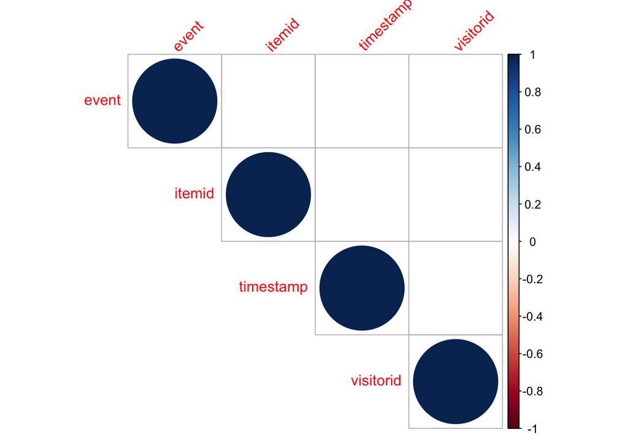

```r
## Step 2 - Correlation Matrix
events2 <- events
events2$event <- as.numeric(events2$event)
events2_x <- subset(events2, select = -5)
datamatrix1 <- cor(events2_x)
corrplot(datamatrix1, order = "hclust", type = "upper", tl.srt = 45)
```

```r
res <- rcorr(as.matrix(events2_x), type = "pearson")
res$r
```

```
##              timestamp    visitorid        event        itemid
## timestamp  1.000000000 0.0059966294 -0.004461532  0.0010933842
## visitorid  0.005996629 1.0000000000  0.001810405  0.0002585838
## event     -0.004461532 0.0018104049  1.000000000 -0.0028924709
## itemid     0.001093384 0.0002585838 -0.002892471  1.0000000000
```

```r
res$P
```

```
##              timestamp   visitorid        event       itemid
## timestamp           NA 0.000000000 1.292300e-13 6.949588e-02
## visitorid 0.000000e+00          NA 2.651041e-03 6.677137e-01
## event     1.292300e-13 0.002651041           NA 1.571310e-06
## itemid    6.949588e-02 0.667713704 1.571310e-06           NA
```

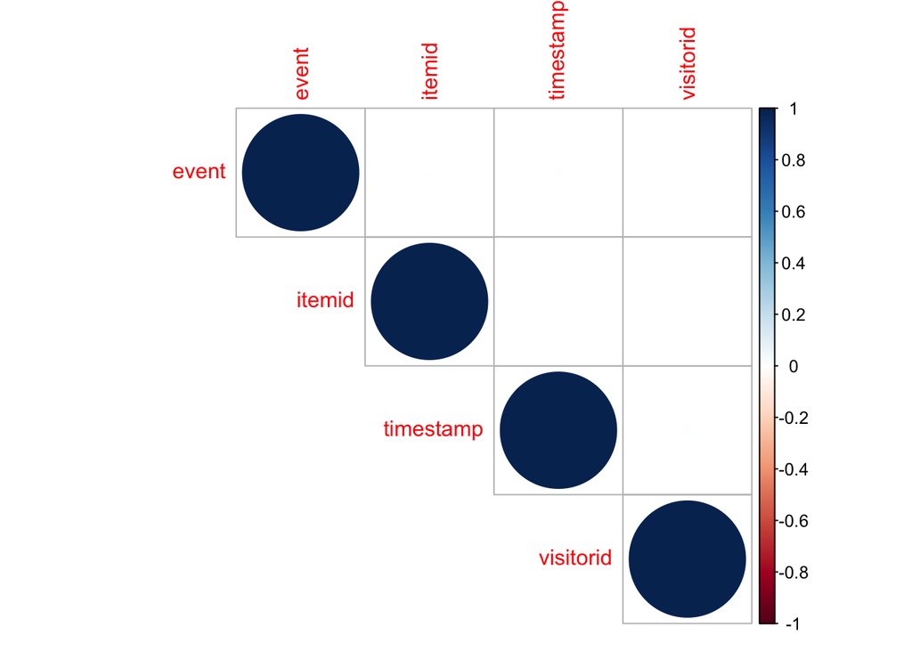

```r
corrplot(res$r, type = "upper", order = "hclust",
         p.mat = res$P, sig.level = 0.01, insig = "blank")
```

#### None of the data is correlated as showing in the graphs. The only important thing to pay attention is the correlation between time and event, which also shows very low correlation.

```r
## Step 3 - KMO
KMO(r=datamatrix1)
```

```
## Kaiser-Meyer-Olkin factor adequacy
## Call: KMO(r = datamatrix1)
## Overall MSA =  0.5
## MSA for each item =
## timestamp visitorid     event    itemid
##       0.5       0.5       0.5       0.5
```

#### Since overall MSA is 0.5 which is less than 0.6, this data is inadequate for factor analysis.

```r
## Step 6 - Regression
events_lr = glm(events$event~., data = events, family = 'binomial')
summary(events_lr)
```

```
##
## Call:
## glm(formula = events$event ~ ., family = "binomial", data = events)
##
## Deviance Residuals:
##        Min          1Q      Median          3Q         Max
## -2.409e-06  -2.409e-06  -2.409e-06  -2.409e-06  -2.409e-06
##
## Coefficients:
##                 Estimate Std. Error z value Pr(>|z|)
## (Intercept)   -2.657e+01  1.022e+06       0        1
## timestamp     -9.766e-23  7.112e-07       0        1
## visitorid     -2.078e-19  5.888e-03       0        1
## itemid         2.205e-18  1.763e-02       0        1
## transactionid -6.232e-17  4.661e-01       0        1
##
## (Dispersion parameter for binomial family taken to be 1)
##
##     Null deviance: 0.0000e+00  on 22456  degrees of freedom
## Residual deviance: 1.3029e-07  on 22452  degrees of freedom
##   (2733644 observations deleted due to missingness)
## AIC: 10
##
## Number of Fisher Scoring iterations: 25
```

```r
vif(events_lr)
```

```
##     timestamp     visitorid        itemid transactionid
##      1.000083      1.000183      1.000021      1.000124
```

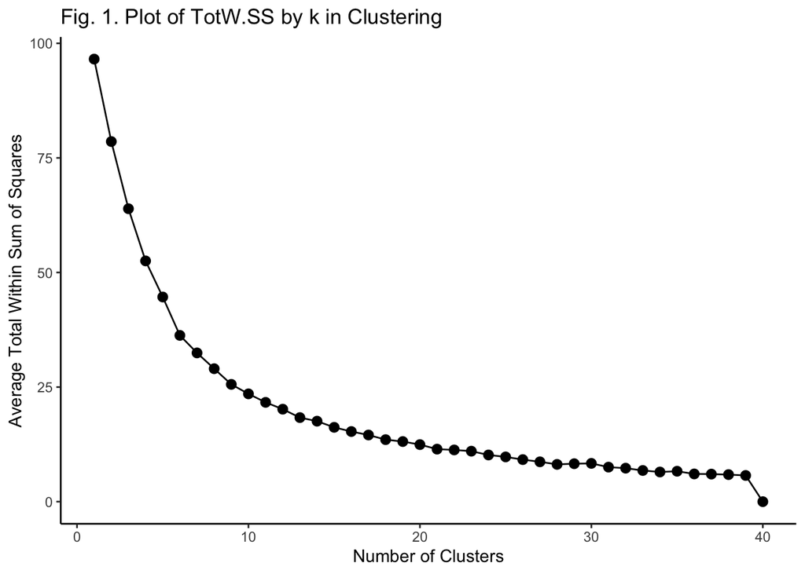

```r
## Find the optimal number of clusters (elbow, gap or silhouette methods)
### Elbow Method
data <- events[1:100,1:4]

dmatrix <- daisy(events[1:100,1:4])

avg.totw.ss <- numeric(40)
for (k in 1:40) {
  totw.ss <- numeric(40)
  for (trial in 1:40) {
    runs <- kmeans(dmatrix, centers=k)
    totw.ss[trial] <- runs$tot.withinss
  }
  avg.totw.ss[k-1] <- mean(totw.ss)
}

ggplot(aes(x,y), data=data.frame("x"=c(1:40), "y"=avg.totw.ss))+geom_line()+geom_point(size=2.5)+labs(x="Number of Clusters", y="Average Total Within Sum of Squares")+ggtitle("Fig. 1. Plot of TotW.SS by k in Clustering")+theme_classic()
```

#### The elbow method helps us determine the percentage of variance explained by k. The optimal k will be chosen when the change rate starts to drop.

#### K-means clustering is the method of vector quantization. It targets to partition numbers of observations into k clusters where each observation belongs to the cluster with the nearest mean.

```r
for (k in 4:8) {
  km <- kmeans(dmatrix, k)
  data <- data.frame(data, km$cluster)
}
colnames(data)[5:9] <- c("km1","km2","km3","km4","km5")
```

#### Hierarchical cluster builds a hierarchy of clusters. There are 2 types of hierarchical clusters: Agglomerative and Divisive. Agglomerative is a "bottom-up" approach which each observation starts in its own cluster, and pairs of clusters are merged as one then move upwards alone the hierarchy. Divisive is a "top-down" approach where all observations start in one cluster then splits are performed recursively as each moves down alone the hierarchy.

```r
hc <- hclust(dmatrix, method="ward.D2")
for (k in 4:8) {
  data <- data.frame(data, cutree(hc, k))
}
colnames(data)[10:14] <- c("hc1","hc2","hc3","hc4","hc5")
```

#### Result of applying different clustering methods is, k=4 is chosen as the number of clusters. This 2-d table compares the distribution of add to cart event, view event and transaction event in each cluster.

```r
table(data$km1, data$event)
```

```
##
##     addtocart transaction view
##   1         0           0   28
##   2         0           0   33
##   3         0           0   36
##   4         3           0    0
```